# PML project - Activity Quality Prediction

### Summary

The present report describes a machine learnig algorithm to predict activity quality from data collected from sensors in portable devices used while performing weight lifting exercises.

### Prerequisites

```r
fileDataName1 <- "./pml-training.csv"
fileDataName2 <- "./pml-testing.csv"
```

The **./pml-training.csv** and **./pml-testing.csv** csv data files should exist in the working directory.

```r
if(file.exists(fileDataName1) && file.exists(fileDataName2)){
  print("training and testing csv data files found, ready to load")
} else {
  stop("either training or testing csv data file not found, execution terminated")
}
```

```
## [1] "training and testing csv data files found, ready to load"
```

### Data loading

Data are loaded from the **./pml-training.csv** and **./pml-testing.csv** files.

```r
trainingDataOr <- read.csv(fileDataName1, header = TRUE)
testingDataOr <- read.csv(fileDataName2, header = TRUE)
```

### Exploratory Data Analysis

Data available are referred to:

- one weight lift exercise, the “Unilateral Dumbbell Biceps Curl”;
- six users: adelmo, carlitos, charles, eurico, jeremy, pedro;
- four sensor devices: arm, forearm, belt, dumbbell;
- five ways the exercise may be performed:
  - classe = “A” exactly according to the specification;
  - classe = “B” throwing the elbows to the front;
  - classe = “C” lifting the dumbbell only halfway;
  - classe = “D” lowering the dumbbell only halfway;
  - classe = “E” and throwing the hips to the front.

A look at the downloaded data.

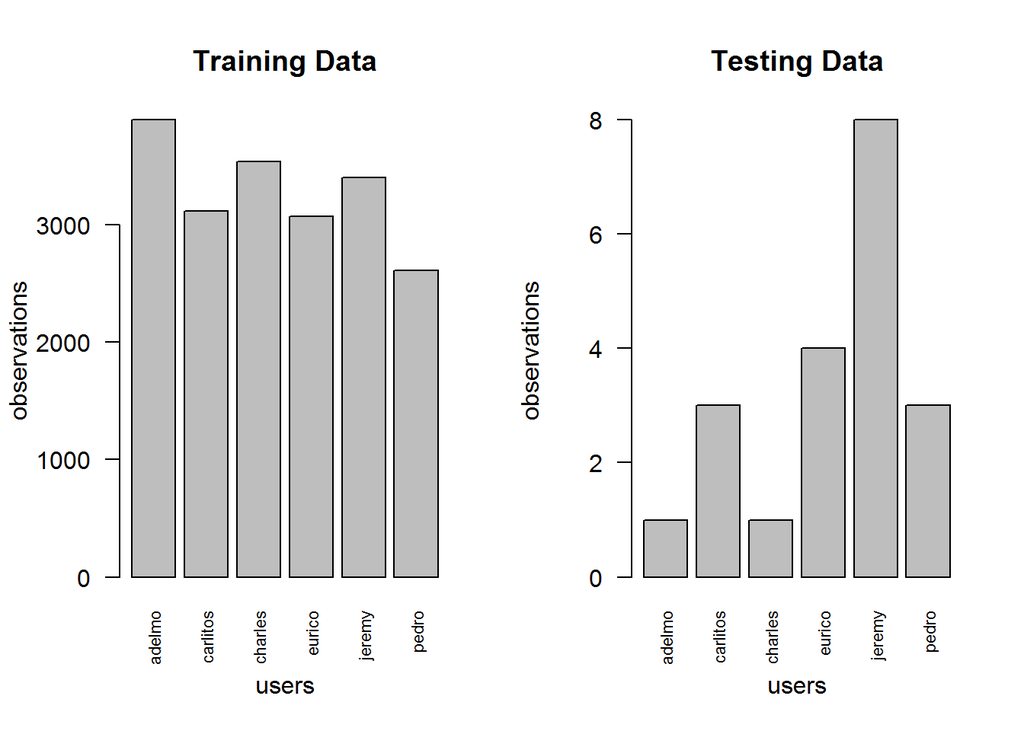

```r
# users in trainingData and in testingData

usersTraining <- unique(trainingDataOr$user_name)
usersTesting <- unique(testingDataOr$user_name)

par(mfrow=c(1,2))
barplot(summary(trainingDataOr$user_name),
        main="Training Data",
        xlab="users",
        ylab="observations",
        cex.names = 0.7,
        las =2)
barplot(summary(testingDataOr$user_name),
        main="Testing Data",
        xlab="users",
        ylab="observations",
        cex.names = 0.7,
        las =2)
```

Quality vs. users as classified in training data.

```r
table(trainingDataOr$user_name,trainingDataOr$classe)
```

```
##
##               A    B    C    D    E
##   adelmo   1165  776  750  515  686
##   carlitos  834  690  493  486  609
##   charles   899  745  539  642  711
##   eurico    865  592  489  582  542
##   jeremy   1177  489  652  522  562
##   pedro     640  505  499  469  497
```

## Partition of the training data

The training data are split in training data (60%) and testing data (40%) for building the model.

```r
# set seed for reproducibility

set.seed(12345)

# packet caret for createDataPartition

library(caret)
```

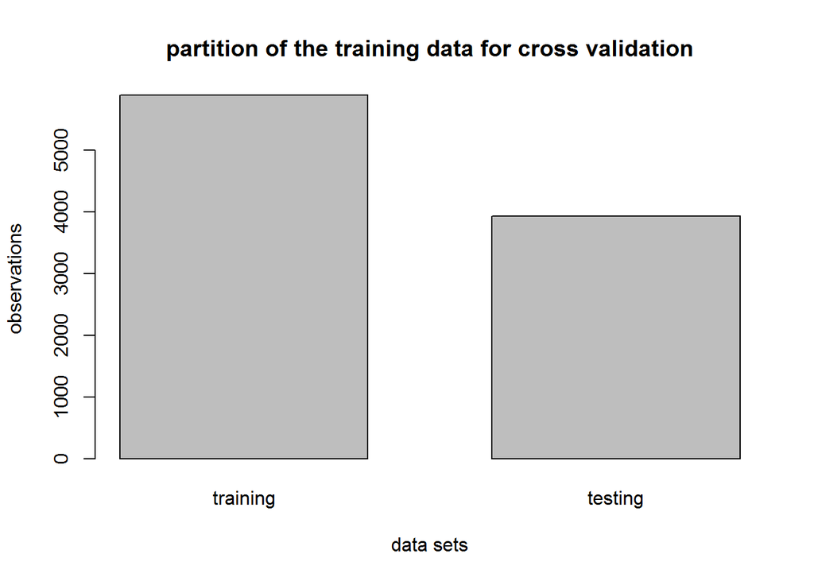

```r
######## only for temporary data reduction ########

# trainingData <- trainingDataOr

inTrainTMP <- createDataPartition(y=trainingDataOr$classe,p=0.5,list=FALSE)
trainingData <- trainingDataOr[inTrainTMP,]

###################################################

inTrain <- createDataPartition(y=trainingData$classe,p=0.6,list=FALSE)

# training data

training <- trainingData[inTrain,]

# testing data

testing <- trainingData[-inTrain,]

# plot of data partitions
par(mfrow=c(1,1))
barplot(c(dim(training)[1],dim(testing)[1]),
        names.arg = c("training","testing"),
        main="partition of the training data for cross validation",
        space = 0.5,
        xlab="data sets",
        ylab="observations")
```

### Pre-processing of the training data

A set of features is selected taking into consideration:

- the physics of the problem;
- the quality of the available data;
- the CPU time and space constraints.

```r
# reduction of features

# interesting features are in:
# ftrSel <- c(2,                    # user name (user_name)
#             8,9,10,11,            # belt sensor (roll_, pitch_,yaw_, total_accel_)
#             46,47,48,49,          # arm sensor (roll_, pitch_,yaw_, total_accel_)
#             84,85,86,102,         # dumbbell sensor (roll_, pitch_,yaw_, total_accel_)
#             122,123,124,140,      # forearm (roll_, pitch_,yaw_, total_accel_)
#             160)                  # this is the classe to be predicted (classe)

ftrSel <- c(2,
            8,9,10,
            46,47,48,
            84,85,86,
            122,123,124,
            160)

training1 <- training[,ftrSel]

testing1 <- testing[,ftrSel]
```

### Model creation - Random Tree Forest

A model is created using the R function *train* in the *caret* packet and using the random forest algorithm.

```r
set.seed(12345)

modFit <- train(classe ~ .,data=training1,method="rf",prox=TRUE)
modFit
```

```
## Random Forest
##
## 5889 samples
##   13 predictor
##    5 classes: 'A', 'B', 'C', 'D', 'E'
##
## No pre-processing
## Resampling: Bootstrapped (25 reps)
## Summary of sample sizes: 5889, 5889, 5889, 5889, 5889, 5889, ...
## Resampling results across tuning parameters:
##
##   mtry  Accuracy   Kappa      Accuracy SD  Kappa SD
##    2    0.9498014  0.9364582  0.004804959  0.006095238
##    9    0.9637466  0.9541311  0.003296009  0.004193648
##   17    0.9553068  0.9434570  0.005060500  0.006405744
##
## Accuracy was used to select the optimal model using  the largest value.
## The final value used for the model was mtry = 9.
```

The model is evaluated against the testing data set.

```r
predictions <- predict(modFit,testing1)

table(predictions,testing1$classe)
```

```
##
## predictions    A    B    C    D    E
##           A 1098   14    0    1    0
##           B   12  716    9    0    5
##           C    4   28  662   13    7
##           D    2    1   10  627    3
##           E    0    0    3    2  706
```

### Model predictions

The testing data in the **./pml-testing.csv** csv file are

```r
testingData1 <- testingDataOr[,ftrSel]

tD1_predictions <- predict(modFit,testingData1)

tD1_predictions
```

```
##  [1] B A B A A E D B A A B C B A E E A B B B
## Levels: A B C D E
```

### References

Velloso, E.; Bulling, A.; Gellersen, H.; Ugulino, W.; Fuks, H. Qualitative Activity Recognition of Weight Lifting Exercises. Proceedings of 4th International Conference in Cooperation with SIGCHI (Augmented Human ’13) . Stuttgart, Germany: ACM SIGCHI, 2013.

Read more: http://groupware.les.inf.puc-rio.br/har#ixzz3mxrnbWue